# Penguins analysis part 1

Statistics & Hypothesis testing - PDA

Lesley Duff

2023-11-06

# Penguins analysis part 1

```r
library(e1071)
library(infer)
library(tidyverse)
penguins <- read_csv("../clean_data/penguins.csv")
```

We are interested in how bill length differ between the three species of penguin (Adelie, Chinstrap & Gentoo) in this dataset.

## 1. Exploratory analysis

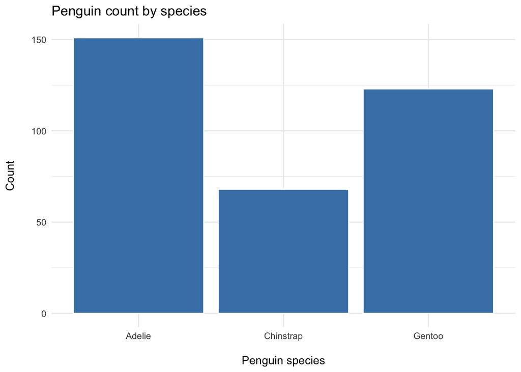

```r
# How many of each species?
penguins %>%
  ggplot() +
  geom_bar(aes(x = species),
    fill = "steelblue",
    colour = "white",
    stat = "count"
  ) +
  theme_minimal() +
  labs(
    x = "\nPenguin species",
    y = "Count\n",
    title = "Penguin count by species",
    fill = "Species"
  )
```

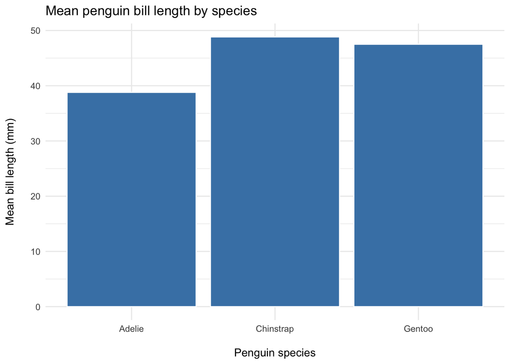

```r
# Calculate mean bill length by species
mean_penguins <- penguins %>%
  select(species, bill_length_mm) %>%
  group_by(species) %>%
  summarise(mean_bill_length_mm = mean(bill_length_mm)) %>%
  arrange(desc(mean_bill_length_mm))

mean_penguins %>%
  ggplot() +
  geom_col(aes(x = species, y = mean_bill_length_mm),
    fill = "steelblue",
    colour = "white"
  ) +
  theme_minimal() +
  labs(
    x = "\nPenguin species",
    y = "Mean bill length (mm)\n",
    title = "Mean penguin bill length by species"
  )
```

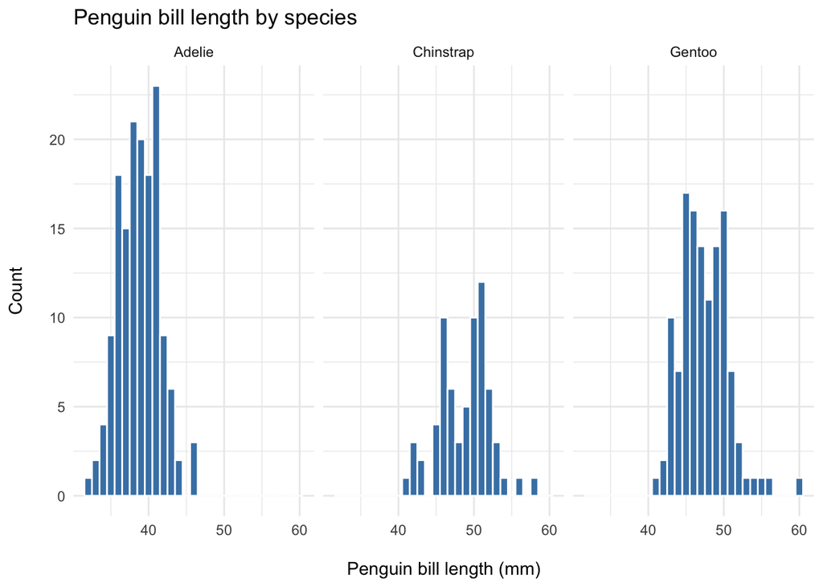

```r
# 4.1 Exploratory data analysis and targeted data analysis (hypothesis testing)
penguins %>%
  ggplot() +
  geom_histogram(
    aes(
      x = bill_length_mm,
      fill = species
    ),
    col = "white",
    fill = "steelblue",
    binwidth = 1
  ) +
  facet_wrap(~species, ncol = 3) +
  theme_minimal() +
  labs(
    x = "\nPenguin bill length (mm)",
    y = "Count\n",
    title = "Penguin bill length by species"
  )
```

```r
mean_penguins
```

| species | mean_bill_length_mm |
| --- | --- |
| Chinstrap | 48.83382 |
| Gentoo | 47.50488 |
| Adelie | 38.79139 |

### Summary

- There are more Adelie penguins than any other species, they have the shortest mean bill length.
- There are fewest of Chinstrap penguins these have the longest mean bill length.
- Chinstrap and Gentoo appear to have a bimodal distribution

## 2. Summary statistics

Calculate the following summary statistics to describe bill length for each species:

- measures of centrality (mean & median)
- spread (standard deviation)
- skewness

### Bill length summary statistics

```r
# 4.4 Summary statistics including measures of centrality, spread and skewness
penguin_summary_stats <- penguins %>%
  group_by(species) %>%
  summarise(
    count = n(),
    range = max(bill_length_mm) - min(bill_length_mm),
    mean = mean(bill_length_mm),
    median = median(bill_length_mm),
    sd = sd(bill_length_mm),
    skewness = skewness(bill_length_mm, type = 1)
  )
penguin_summary_stats
```

| species | count | range | mean | median | sd | skewness |
| --- | --- | --- | --- | --- | --- | --- |
| Adelie | 151 | 13.9 | 38.79139 | 38.80 | 2.663405 | 0.16006382 |
| Chinstrap | 68 | 17.1 | 48.83382 | 49.55 | 3.339256 | -0.08856427 |
| Gentoo | 123 | 18.7 | 47.50488 | 47.30 | 3.081857 | 0.64316334 |

- Adelie = fairly symmetrical, slight right skew
- Chinstrap = fairly symmetrical, with slight left skew, highest standard deviation, observations are more spread out
- Gentoo = moderately right skewed

## 3. Hypothesis test & probability

Perform a suitable hypothesis test to check whether the mean bill length of Gentoo is significantly longer than the mean bill length of Adelie.

Mean bill length Gentoo = 47.50488

Mean bill length Adelie = 38.79139

With two species of penguins a two-sample test would seem appropriate. Each observation in the Gentoo samples does not have a connection with another observation in the Adelie samples. The samples are *independent*.

This will be a one-tailed test - a statistical hypothesis test in which the critical area of a distribution is one-sided so that it is either greater than or less than a certain value, but not both.

**Null hypothesis:**

$H_0$: $\mu_{\textrm{bill_length_mm}}(Gentoo)$−$\mu_{\textrm{bill_length_mm}}(Adelie)$=0

**alternative hypothesis:**

$H_a$: $\mu_{\textrm{bill_length_mm}}(Gentoo)$−$\mu_{\textrm{bill_length_mm}}(Adelie)$>0

Set the conventional significance level $\alpha = 0.05$

Visualise the distributions and check the sizes of both samples.

```r
penguins_gentoo_adelie <- penguins %>%
  filter(species %in% c("Gentoo", "Adelie"))

penguins_gentoo_adelie %>%
  group_by(species) %>%
  summarise(n = n())
```

| species | n |
| --- | --- |
| Adelie | 151 |
| Gentoo | 123 |

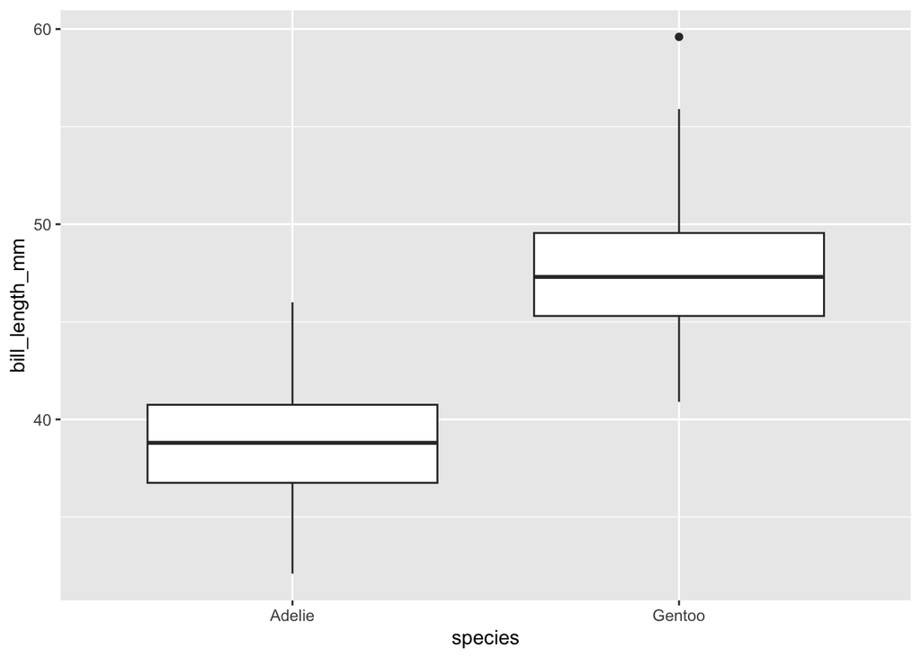

```r
penguins_gentoo_adelie %>%
  ggplot(aes(y = bill_length_mm, x = species)) +
  geom_boxplot()
```

The average seems quite different and higher for Gentoo. This shows that Gentoo bill lengths are higher.

To check whether this difference in distributions could be down to sampling variation (i.e. it may have occurred ‘by chance’) or whether it is a statistically significant difference we will perform our hypothesis test.

A null distribution is a theoretical distribution of a statistical test statistic that represents what you would expect to observe if the null hypothesis were true.

We use **permutation** to generate our null distribution. This is chosen as it carries out a randomisation test for independence between two variables and is good for dealing with relatively small sample sizes. Permutation is less likely to produce false-positive results (Type I errors).

- Under $H_0$ the species of the penguin would have no bearing on the mean bill length, i.e. the species and mean bill length are independent. There would be no difference between species.
- Permuting by randomly shuffling the species labels we lose any relationship that there was between species and mean bill length. If there is no relationship and they are independent then randomly shuffling them should have no implication. If the difference between species is much larger than the difference once the labels are shuffled it’s because there is a real difference between the species, and it’s not just down to sampling variation.

Once we shuffle the species labels, we calculate the sample statistic which is the difference in mean bill length for each species. We repeat the shuffle and calculation of mean bill length many times i.e. ‘reps’ to create the null distribution. In the following examples we generate 10000 reps.

```r
# 4.1 Exploratory data analysis and targeted data analysis (hypothesis testing)
# 4.3 Probability and probability distributions

# define a null distribution
null_distribution <- penguins_gentoo_adelie %>%
  # We test the relationship between bill_length_mm and species
  specify(bill_length_mm ~ species) %>%

  #the null hypothesis is there is no relationship i.e. they are independent
  hypothesize(null = "independence") %>%

  # Generates a distribution of 10000 resamples
  generate(reps = 10000, type = "permute") %>%

  #return the observed statistic specified with the stat argument
  # sample stat is mean of Gentoo minus mean of Adelie,
  # so this is the order we specify in the calculate step
  # Calculates the difference between the mean of Gentoo minus mean of Adelie
  calculate(stat = "diff in means", order = c("Gentoo", "Adelie"))

head(null_distribution)
```

| replicate | stat |
| --- | --- |
| 1 | 0.52579551 |
| 2 | 0.90051150 |
| 3 | -0.03775373 |
| 4 | -0.28559737 |
| 5 | -0.01562483 |
| 6 | -0.29739945 |

```r
# calculate the observed statistic
observed_stat <- penguins_gentoo_adelie %>%
  # We test the relationship between bill_length_mm and species
  specify(bill_length_mm ~ species) %>%
  calculate(stat = "diff in means", order = c("Gentoo", "Adelie"))

observed_stat
```

| stat |
| --- |
| 8.713487 |

Visualise the null distribution and where the observed statistic lies on the distribution.

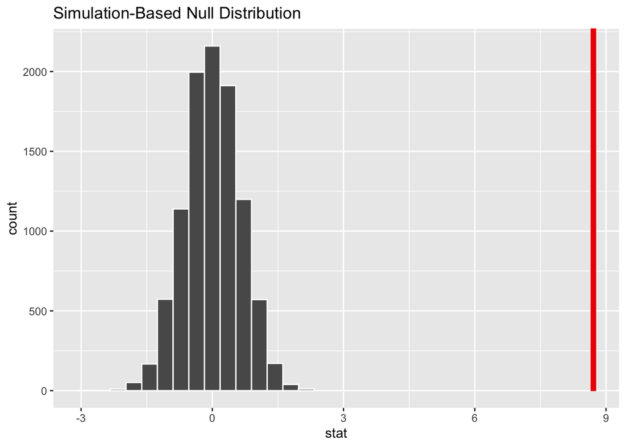

```r
null_distribution %>%
  visualise()+

  # one-tailed test because alternative is that the difference is greater
  # than zero i.e. right direction
  shade_p_value(obs_stat = observed_stat,
                direction = "right")
```

```r
# calculate a p-value
p_value <- null_distribution %>%
  get_p_value(obs_stat = observed_stat,
              direction = "right")
p_value
```

| p_value |
| --- |
| 0 |

The observed statistic is on the extreme right edge of our null distribution. So there would be a very small probability of getting a more extreme value than this under $H_0$.

**p < 0.001 is very small**, the observed difference is unlikely to be due to chance. A true p-value of 0 is impossible, This is due to the simulation-based nature of the {infer} package.

Our null hypothesis was that “There is no difference between mean bill lengths of Gentoo and Adelie species.”. We simulated a test statistic under the null hypothesis. However this probability was extremely low and very unlikely so there is a very statistically significant difference between mean bill lengths of the two species of penguin.

The p-value is less than $\alpha$ = 0.05 so we reject $H_0$. We reject the null hypothesis and conclude that there is **strong** evidence that the **mean bill length of Gentoo is significantly longer than the mean bill length of Adelie**.